# STAT 516 Lec 01

Inference on the mean and variance of a Normal population

Karl Gregory

2026-10-26

# Setup

Throughout let $X_1,\dots,X_n \overset{\operatorname{ind}}{\sim} \mathcal{N}(\mu,\sigma^2)$.

In this lecture we review how to:

1. Estimate $\mu$ and $\sigma^2$.
2. Build confidence intervals for $\mu$ and $\sigma^2$.
3. Test hypotheses concerning $\mu$ and $\sigma^2$.
4. Choose the sample size.

We call $X_1,\dots,X_n$ a random sample.

# Golden ratio example

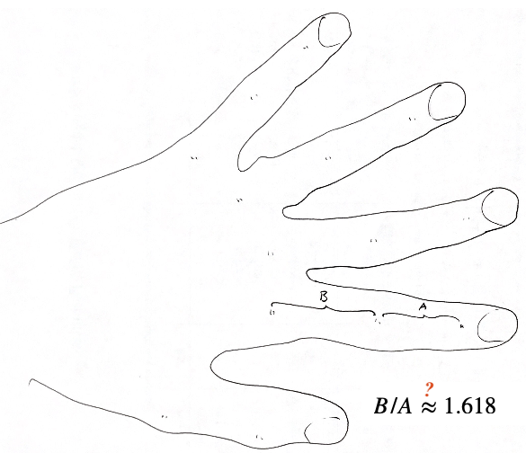

A class of $n = 27$ students measured $B/A$ on themselves:

```r
gr <- c(1.66, 1.61, 1.62, 1.69, 1.58, 1.43, 1.66,
        1.69, 1.58, 1.20, 1.52, 1.60, 1.55, 1.67,
        1.77, 1.50, 1.64, 1.54, 1.40, 1.36, 1.50,
        1.40, 1.35, 1.48, 1.64, 1.91, 1.70)
```

What is the true mean of $B/A$? Could it be the golden ratio?!?

# Golden ratio

Check if $B/A$ measurements come from a Normal distribution.

```r
qqnorm(scale(gr))
abline(0,1)
```

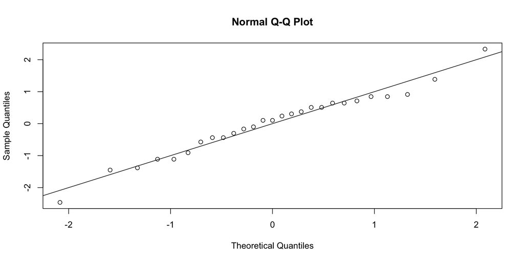

# Estimation

Based on $X_1,\dots,X_n$, define the sample statistics

- $\displaystyle \bar X_n = \frac{1}{n}\sum_{i=1}^n X_i$
- $\displaystyle S_n^2 = \frac{1}{n-1}\sum_{i=1}^n(X_i - \bar X_n)^2$

Then $\bar X_n$ and $S_n^2$ are unbiased estimators of $\mu$ and $\sigma^2$, respectively.

# Golden ratio

We have $\bar X_n =$ `mean(gr)` $= 1.565$ and $S_n^2 =$ `var(gr)` $= 0.022$.

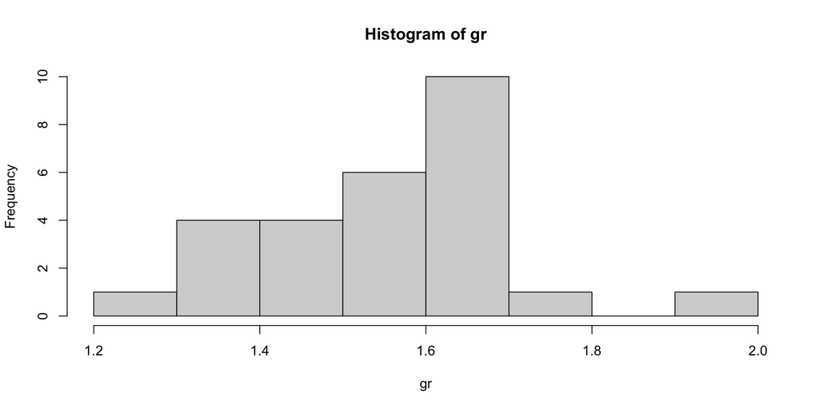

```r
hist(gr)
```

# Important sampling distribution results

Provided $X_1,\dots,X_n \overset{\operatorname{ind}}{\sim} \mathcal{N}(\mu,\sigma^2)$, we have

- $\displaystyle \frac{\bar X_n - \mu}{\sigma/\sqrt{n}} \sim \mathcal{N}(0,1)$
- $\displaystyle \frac{(n-1)S_n^2}{\sigma^2} \sim \chi_{n-1}^2$
- $\displaystyle \frac{\bar X_n - \mu}{S_n/\sqrt{n}} \sim t_{n-1}$

# Anatomy of chi-square and t random variables

- $\displaystyle Z_1,\dots,Z_m \overset{\operatorname{ind}}{\sim} \mathcal{N}(0,1) \implies Z_1^2 + \dots + Z_m^2 \sim \chi^2_m$.
- $\displaystyle Z \sim \text{Normal(0,1)} \perp \!\!\! \perp W \sim \chi^2_m \implies \frac{Z}{\sqrt{W/m}} \sim t_m$.

Relate these to the results on the previous slide.

# Simulation illustrating sampling distribution results

```r
sims <- 1000
mu <- 1
sigma <- 1/2
n <- 8
Tn <- numeric(sims)
Wn <- numeric(sims)
for(s in 1:sims){

  X <- rnorm(n,mu,sigma)
  sn <- sd(X)
  xbar <- mean(X)
  Tn[s] <- sqrt(n)*(xbar - mu) / sn
  Wn[s] <- (n-1)*sn^2 / sigma^2

}
```

# Simulation illustrating sampling distribution results

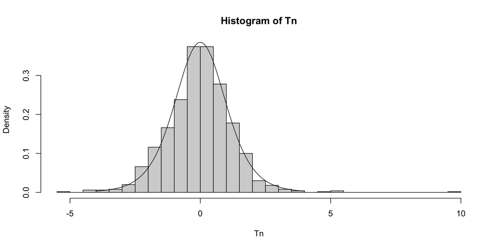

```r
hist(Tn,freq = FALSE,breaks = 50)
x <- seq(-4,4,length = 500)
lines(dt(x,n-1)~x)
```

# Simulation illustrating sampling distribution results

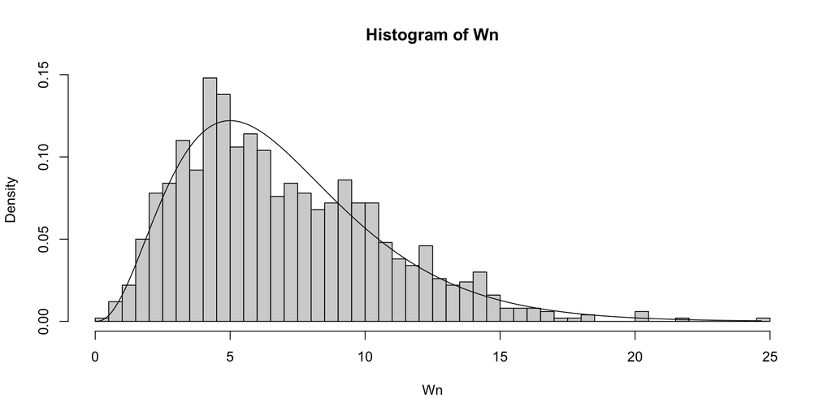

```r
hist(Wn,freq = FALSE,breaks = 50)
x <- seq(0,max(Wn),length = 500)
lines(dchisq(x,n-1)~x)
```

# Confidence intervals for the mean and variance

The sampling distribution results give $(1-\alpha)100\%$ CIs as

- $\displaystyle \bar X_n \pm t_{n-1,\alpha/2} \frac{S_n}{\sqrt{n}}$ for $\mu$.
- $\displaystyle \Big[\frac{(n-1)S_n^2}{\chi^2_{n-1,\alpha/2}},\frac{(n-1)S_n^2}{\chi^2_{n-1,1-\alpha/2}}\Big]$ for $\sigma^2$.

Derive the above.

# Golden ratio

Build $95\%$ CIs for population mean and variance of $B/A$ values:

```r
alpha <- 0.05
n <- length(gr)

lomu <- mean(gr) - qt(1-alpha/2,n-1) * sd(gr)/sqrt(n)
upmu <- mean(gr) + qt(1-alpha/2,n-1) * sd(gr)/sqrt(n)

losgs <- (n-1) * var(gr) / qchisq(1-alpha/2,n-1)
upsgs <- (n-1) * var(gr) / qchisq(alpha/2,n-1)
```

The $95\%$ CI for $\mu$ is $[1.506,1.623]$. For $\sigma^2$ it is $[0.014,0.041]$.

# Testing hypotheses about the mean

Consider testing hypotheses about $\mu$ of the form
$$\begin{array}{lclcl}
H_0\text{: } \mu \geq \mu_0 &\text{ or } & H_0\text{: } \mu = \mu_0 &\text{ or } & H_0\text{: } \mu \leq \mu_0\\
H_1\text{: } \mu < \mu_0 && H_1\text{: } \mu \neq \mu_0 && H_1\text{: } \mu > \mu_0.
\end{array}$$
Reject or fail to reject $H_0$ based on the value of the test statistic
$$T_{\operatorname{test}}= \frac{\bar X_n - \mu_0 }{S_n / \sqrt{n}}.$$
Rejection rules for the above at significance level $\alpha$ are
$$\begin{array}{lclcl}
T_{\operatorname{test}}< -t_{n-1,\alpha} &\text{ or } & |T_{\operatorname{test}}| > t_{n-1,\alpha/2}&\text{ or } & T_{\operatorname{test}}> t_{n-1,\alpha}.
\end{array}$$

The corresponding p-values are, with $T \sim t_{n-1}$, the probabilities
$$\begin{array}{lclcl}
P(T < T_{\operatorname{test}}) &\text{ or } & 2 \times P(T > |T_{\operatorname{test}}|) & \text{ or } & P(T > T_{\operatorname{test}}).
\end{array}$$

# Golden ratio

Test $H_0$: $\mu = 1.618$ vs $H_1$: $\mu \neq 1.618$ at $\alpha = 0.05$ based on data.

```r
alpha <- 0.05
Ttest <- (mean(gr) - 1.618) / (sd(gr) / sqrt(n))
Tcrit <- qt(1-alpha/2,n-1)
```

Fail to reject $H_0$ since $T_{\operatorname{test}}= -1.866$ is smaller in absolute value than $t_{n-1,\alpha/2} = 2.056$.

```r
pval <- 2*(1 - pt(abs(Ttest),n-1))
```

Equivalently, the p-value, which is 0.073, is greater than $\alpha = 0.05$.

# Golden ratio

Demonstrate the `t.test()` function in R:

The function `t.test()` tests $H_0$: $\mu = 0$ vs $H_1$: $\mu \neq 0$ by default.

```r
t.test(gr)
```

```
    One Sample t-test

data:  gr
t = 55, df = 26, p-value <2e-16
alternative hypothesis: true mean is not equal to 0
95 percent confidence interval:
 1.51 1.62
sample estimates:
mean of x
     1.56
```

# Golden ratio

Now test $H_0$: $\mu = 1.618$ versus $H_1$: $\mu \neq 1.618$, ask for 99% CI.

```r
t.test(gr, mu = 1.618, conf.level = 0.99)
```

```
    One Sample t-test

data:  gr
t = -2, df = 26, p-value = 0.07
alternative hypothesis: true mean is not equal to 1.62
99 percent confidence interval:
 1.49 1.64
sample estimates:
mean of x
     1.56
```

# Golden ratio

Now test $H_0$: $\mu \leq 1.618$ versus $H_1$: $\mu > 1.618$.

```r
t.test(gr, mu = 1.618, alternative = "greater")
```

```
    One Sample t-test

data:  gr
t = -2, df = 26, p-value = 1
alternative hypothesis: true mean is greater than 1.62
95 percent confidence interval:
 1.52  Inf
sample estimates:
mean of x
     1.56
```

# Testing hypotheses about the variance

Consider testing hypotheses about $\sigma^2$ of the form
$$\begin{array}{lcl}
H_0\text{: } \sigma^2 \geq \sigma^2_0 &\text{ or } & H_0\text{: } \sigma^2 \leq \sigma^2_0 \\
H_1\text{: } \sigma^2 < \sigma^2_0 && H_1\text{: } \sigma^2 > \sigma^2_0
\end{array}$$
Reject or fail to reject $H_0$ based on the value of the test statistic
$$W_{\operatorname{test}}= \frac{(n-1)S_n^2 }{\sigma_0^2}.$$
Rejection rules for the above at significance level $\alpha$ are
$$\begin{array}{lclcl}
W_{\operatorname{test}}< \chi^2_{n-1,1-\alpha} &\text{ or } & W_{\operatorname{test}}> \chi^2_{n-1,\alpha}
\end{array}$$

The corresponding p-values are, with $W \sim \chi^2_{n-1}$, the probabilities
$$\begin{array}{lclcl}
P(W < W_{\operatorname{test}}) & \text{ or } & P(W > W_{\operatorname{test}}).
\end{array}$$

# Golden ratio

Test $H_0$: $\sigma^2 \geq 0.03$ vs $H_1$: $\sigma^2 < 0.03$ at $\alpha = 0.05$ based on data.

```r
alpha <- 0.05
Wtest <- (n-1)*var(gr) / 0.03
Wcrit <- qchisq(alpha,n-1)
```

Fail to reject $H_0$ since $W_{\operatorname{test}}= 19.009$ exceeds $\chi_{n-1,1-\alpha}^2 = 15.379$.

```r
pval <- pchisq(Wtest,n-1)
```

Equivalently, the p-value, which is $0.164$, is greater than $\alpha = 0.05$.

# Pallet weights example

The weights in lbs of several wooden pallets were recorded.

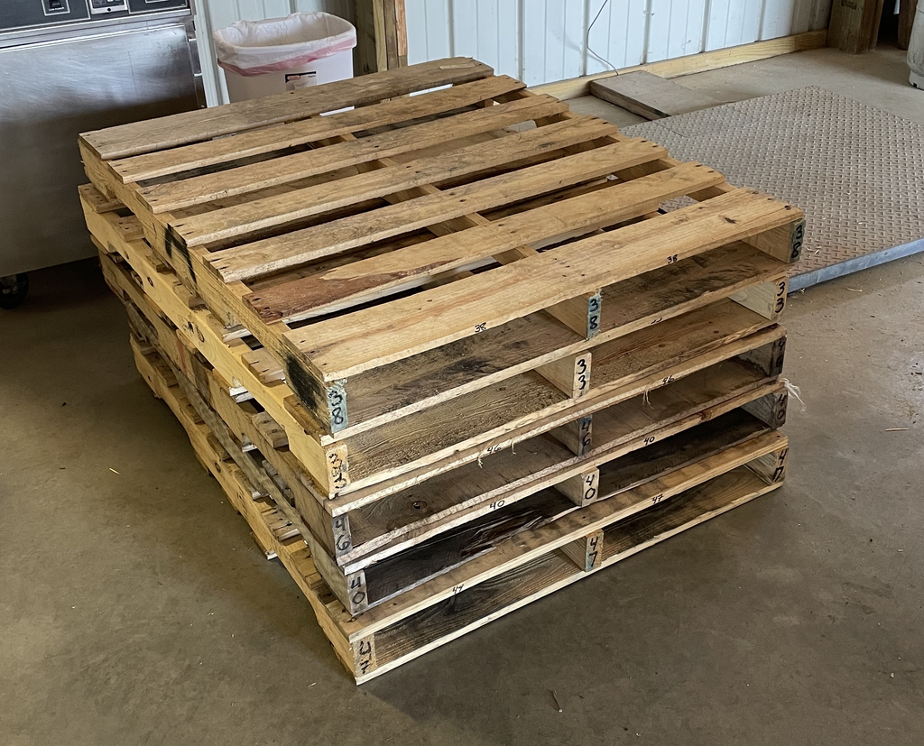

[figure not shown]

```r
wt <- c(41,34,40,44,33,42,52,38,32,31,31,35,
        39,44,42,42,35,33,40,48,51,32,41,35,
        38,48,37,35,42,41,40,47,40,46,33,38,
        51,39,40)
```

# Pallet weights

- Check if we can assume normally distributed pallet weights.
- Build a $95\%$ CI for the mean pallet weight assuming $\sigma = 5$.
- Build a $95\%$ CI for the mean pallet weight assuming $\sigma$ is unknown.
- Test at $\alpha = 0.05$ whether the mean pallet weight is equal to $48$ lbs.
- Test at $\alpha = 0.05$ whether the mean pallet weight is less than $40$ lbs.

# Sample size calculations

We can choose a sample size based on the desired:

1. Width of a confidence interval.
2. Power of a test to reject $H_0$ when it is false.

# Sample size required to achieve desired CI width

A CI for $\mu$ takes the form $\bar X_n \pm M$, where

- $\displaystyle M = z_{\alpha/2}\frac{\sigma}{\sqrt{n}}$ if $\sigma$ is known
- $\displaystyle M = t_{n-1,\alpha/2}\frac{S_n}{\sqrt{n}}$ if $\sigma$ is unknown

For ease, use the “$\sigma$-known” version.

If one wants $M \leq M^*$, find smallest $n$ such that $\displaystyle z_{\alpha/2}\frac{\sigma}{\sqrt{n}} \leq M^*$.

So take $\displaystyle n = \left\lceil \left(\frac{z_{\alpha/2}\sigma}{M^*}\right)^2\right \rceil$, where $\lceil \cdot \rceil$ rounds up.

Must put in a guess for $\sigma$.

# Golden ratio

Find $n$ required to make the $95\%$ CI for $\mu$ no wider than $0.08$.

```r
alpha <- 0.05
M <- 0.08/2
sigma_guess <- sd(gr)
nr <- ceiling((qnorm(1-alpha/2) * sigma_guess / M)^2)
```

The required sample size is $53$.

# Pallet weights

- Recommend a sample size likely to give a $95\%$ confidence interval for the mean pallet weight with margin of error no greater than $1$ lb.

# Sample size required to achieve desired power

The power of a test is the probability with which it rejects $H_0$.

For tests of $H_0$ concerning the mean $\mu$ we write the power as
$$\gamma(\mu) = P(\text{Reject $H_0$ when true mean is $\mu$}) = P_\mu(\text{Reject $H_0$}).$$

So the power depends on the true value of $\mu$, i.e. is a function of $\mu$.

# Exercise

Derive the power functions for the tests of
$$\begin{array}{lclcl}
H_0\text{: } \mu \geq \mu_0 &\text{ and } & H_0\text{: } \mu = \mu_0 &\text{ and } & H_0\text{: } \mu \leq \mu_0\\
H_1\text{: } \mu < \mu_0 && H_1\text{: } \mu \neq \mu_0 && H_1\text{: } \mu > \mu_0
\end{array}$$
with the rejection rules
$$\begin{array}{lclcl}
Z_{\operatorname{test}}< -z_\alpha &\text{ and } & |Z_{\operatorname{test}}| > z_{\alpha/2}&\text{ and } & Z_{\operatorname{test}}> z_\alpha,
\end{array}$$
respectively, where $\displaystyle Z_{\operatorname{test}}= \frac{\bar X_n - \mu_0}{\sigma/\sqrt{n}}$ ($\sigma$-known case).

# Power curves for right-, left-, and two-sided tests

Set $\mu_0 = 1.618$, $n = 27$, and $\alpha = 0.05$ and use $\sigma = 0.148$.

```r
alpha <- 0.05
mu0 <- 1.618
sigma <- sd(gr)
n <- length(gr)
mu <- seq(mu0-4*sigma/sqrt(n),mu0+4*sigma/sqrt(n),length=500)
za <- qnorm(1-alpha)
za2 <- qnorm(1-alpha/2)
d <- sqrt(n) * (mu - mu0) / sigma
rp <- 1 - pnorm(za - d)
lp <- pnorm(-za - d)
rp2 <- 1 - pnorm(za2 - d)
lp2 <- pnorm(-za2 - d)
tsp <- lp2 + rp2
```

# Power curves for right-, left-, and two-sided tests

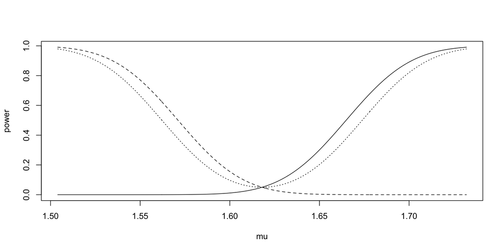

```r
plot(rp ~ mu, type = "l", ylab = "power", xlab = "mu")
lines(lp ~ mu, lty = 2)
lines(tsp ~ mu, lty = 3)
```

# Power curve for right-sided test at various sample sizes

Test $H_0$: $\mu \leq 1.618$ vs $H_1$: $\mu > 1.618$. Use $\alpha = 0.05$ and $\sigma = 0.148$.

```r
alpha <- 0.05
mu0 <- 1.618
sigma <- sd(gr)
n <- length(gr)
mu <- seq(mu0-1*sigma/sqrt(n),mu0+4*sigma/sqrt(n),length=500)
za <- qnorm(1-alpha)

# various sample sizes
nn <- c(10,20,30,40,50,60)
rp <- matrix(NA,500,length(nn))
for(j in 1:length(nn)){
  d <- sqrt(nn[j]) * (mu - mu0) / sigma
  rp[,j] <- 1 - pnorm(za - d)
}
```

# Power curve for right-sided test at various sample sizes

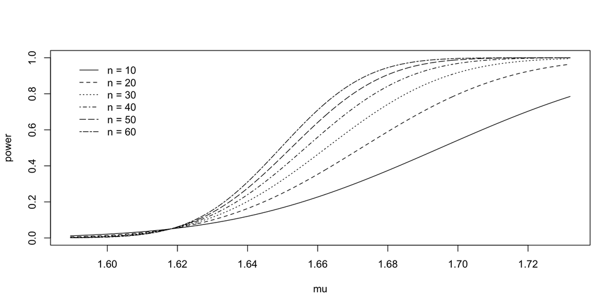

```r
plot(NA,xlim = range(mu), ylim = c(0,1), ylab = "power", xlab = "mu")
for(j in 1:length(nn)) lines(rp[,j] ~ mu, lty = j)
legend(x = min(mu), y = 1,legend = paste("n =",nn),lty = 1:length(nn),bty = "n")
```

# Sample size based on desired power

To find the smallest sample size guaranteeing a desired power:

1. Fix an alternative value $\mu^*$ and a desired power $\gamma^*$.
2. Set up the equation $\gamma(\mu^*) = \gamma^*$ and solve for $n$ (then round up).

For our tests concerning $\mu$ when $\sigma$ is known, we obtain:

- In the one-sided case $\displaystyle n = \bigg\lceil \sigma^2 \Big(\frac{z_\alpha + z_{\beta^*} }{\mu^* - \mu_0}\Big)^2\bigg\rceil$.
- In the two-sided case $\displaystyle n = \bigg\lceil \sigma^2 \Big(\frac{z_{\alpha/2} + z_{\beta^*} }{\mu^* - \mu_0}\Big)^2\bigg\rceil$.

In the above $\beta^* = 1 - \gamma^*$.

# Exercise

Derive the sample size formula for the test of
$$\text{$H_0$: $\mu \leq \mu_0$ vs $H_1$: $\mu > \mu_0$}$$
when $\sigma$ is known.

# Golden ratio

Suppose the true mean of $B/A$ in the population is $1.65$.

Give the sample size $n$ required to reject $H_0$: $\mu \leq 1.618$ vs $H_1$: $\mu > 1.618$ with power $\geq 0.80$. Use $S_n = 0.148$ as a guess of $\sigma$.

```r
alpha <- 0.05
gm <- 0.80
sigma <- sd(gr)
mu <- 1.65
mu0 <- 1.618
za <- qnorm(1 - alpha)
zb <- qnorm(gm)
nr <- ceiling(sigma^2 * (za + zb)^2 / (mu - mu0)^2)
```

The required sample size is $133$.